# Reproducible Research: Peer Assessment 1

## Loading and preprocessing the data

Before we go and download the data, let’s first grab the date: 2017-10-28. Next get the data from the web. The file comes from a repository in my GitHub account that was forked from the original.

```r
source_url <- "https://raw.githubusercontent.com/ASonCourse/RepData_PeerAssessment1/master/activity.zip"

download.file(source_url, destfile = "activity.zip",
              method = "curl")
```

The downloaded file was compressed, so we will unzip it now:

```r
unzip("activity.zip", exdir = ".")
```

It turns out the unzipped file is a comma separated file. We can import that into R easily:

```r
activity <- read.csv("activity.csv", stringsAsFactors = FALSE)
```

The `date` variable in `activity` is of type character and needs to be converted to `date`:

```r
activity$date <- as.Date(activity$date, format = "%Y-%m-%d")
```

This concludes the loading and preprocessing of the data. [Element #1 required for a complete submission (“Code for reading in the dataset and/or processing the data.”)]

## What is mean total number of steps taken per day?

Since we’ll be using `group_by()` and related commands to figure this out we need to install and load the `dplyr` package:

```r
options(repos="https://cran.rstudio.com" )
if (!require(dplyr)) install.packages("dplyr")
library(dplyr)
```

NOTE:

Installing packages by means of R Markdown (`knitr` document) is not advised. The consensus seems to be that users should manage their own package library. We should assume that people know how to install a missing package. Here we’ve opted to download and install the package *only* if it’s necessary. Arguably a number of users might have dplyr installed / loaded already. See this [resource](https://stackoverflow.com/questions/33969024/install-packages-fails-in-knitr-document-trying-to-use-cran-without-setting-a) for more on the subject.

Calculate mean total number of steps per day:

```r
mean_total_steps <- activity %>%
  group_by(date) %>%
  summarise (daily_steps = sum(steps)) %>%
  summarise(mean_total_steps = mean(daily_steps, na.rm = TRUE))

mean_steps <- round(mean_total_steps, 0)
```

```r
median_total_steps <- activity %>%
  group_by(date) %>%
  summarise (daily_steps = sum(steps)) %>%
  summarise(mean_total_steps = median(daily_steps, na.rm = TRUE))

median_steps <- round(mean_total_steps, 0)
```

How about a plot? Yes, let’s create a histogram of the total number of steps taken each day:

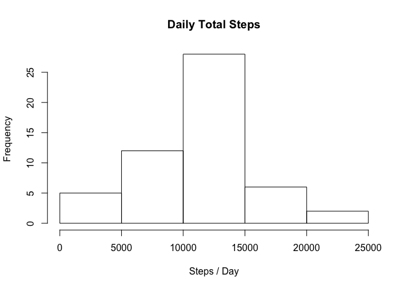

```r
steps_by_day <- activity %>%
  group_by(date) %>%
  summarise (daily_steps = sum(steps))

hist(steps_by_day$daily_steps,
    main = "Daily Total Steps",
    xlab = "Steps / Day")
```

An alternative way of visualizing the total number of steps taken each day is by means of a boxplot:

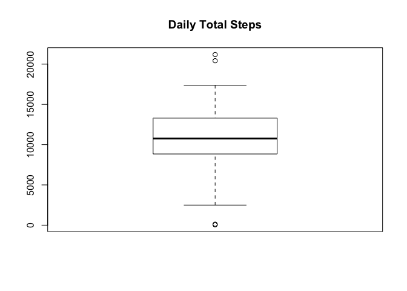

```r
boxplot(steps_by_day$daily_steps,
    main = "Daily Total Steps")
```

## What is the average daily activity pattern?

To show the daily activity pattern we have to group and summarise the data by interval first:

```r
steps_by_interval <- activity %>%
  group_by(interval) %>%
  summarise (av_steps = mean(steps, na.rm = TRUE))
```

Once we’ve done that it’s relatively easy to create a time-series plot:

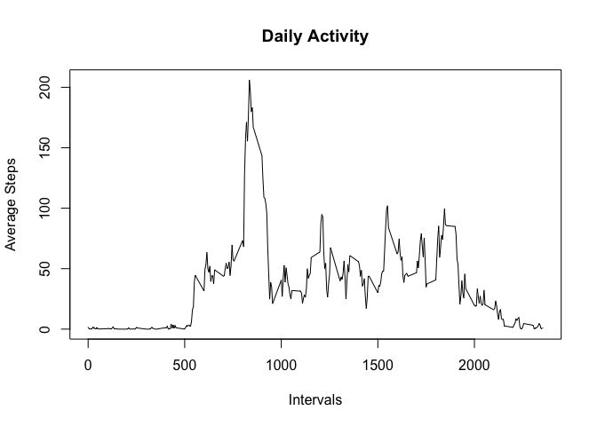

```r
plot(steps_by_interval$av_steps, x = steps_by_interval$interval,
     type = "l",
     main = "Daily Activity",
     xlab = "Intervals",
     ylab = "Average Steps")
```

[Element #4 required for a complete submission (“Time series plot of the average number of steps taken.”)]

What’s the 5-minute interval with the highest number of steps (on average)? Judging from the plot we can guess that it should be around 800. Luckily, we can figure it out exactly:

```r
max_steps <- steps_by_interval[which.max(steps_by_interval$av_steps),]
max_steps_round <- round(max_steps$av_steps, 0)
```

So, the highest number of steps (on average) is 206. The corresponding interval is 835. [Element #5 required for a complete submission (“The 5-minute interval that, on average, contains the maximum number of steps.”)]

## Imputing missing values

So, there are missing values in the dataset (NA’s). How many of them are there, exactly? Simply calling `summary()` on `activity` will tell us:

```r
summary(activity)
```

```
##      steps             date               interval
##  Min.   :  0.00   Min.   :2012-10-01   Min.   :   0.0
##  1st Qu.:  0.00   1st Qu.:2012-10-16   1st Qu.: 588.8
##  Median :  0.00   Median :2012-10-31   Median :1177.5
##  Mean   : 37.38   Mean   :2012-10-31   Mean   :1177.5
##  3rd Qu.: 12.00   3rd Qu.:2012-11-15   3rd Qu.:1766.2
##  Max.   :806.00   Max.   :2012-11-30   Max.   :2355.0
##  NA's   :2304
```

Alternatively, we can filter out `activity` observations where `steps` is NA and subsequently count the number of rows the filtered dataframe has:

```r
na_activity <- activity %>% filter(is.na(steps) == TRUE)
total_number_NAs <- nrow(na_activity)
```

The result of this operation is: 2304 NA’s. In relative terms this represents only a fraction of the original dataset (0.1311475), though.

How to deal with these NA’s? Well, that depends. We have to know a bit more about the NA’s. How are they spread accross the dates / days? The following code delivers the answer to that question:

```r
na_by_day <- na_activity %>%
  group_by(date) %>%
  summarise(na_count = n())
na_by_day
```

```
## # A tibble: 8 x 2
##         date na_count
##       <date>    <int>
## 1 2012-10-01      288
## 2 2012-10-08      288
## 3 2012-11-01      288
## 4 2012-11-04      288
## 5 2012-11-09      288
## 6 2012-11-10      288
## 7 2012-11-14      288
## 8 2012-11-30      288
```

The NA’s seem to be occuring on only 8 days. Judging by the number of NA’s for each day (8 times 288) we can conclude that data for complete days are missing (all 288 intervals (12 x 24)). How are these 8 days without data spread accross the total number of days? What days are missing? Always the same days or does it vary? Let’s find out:

```r
na_by_day$weekday <- weekdays(na_by_day$date)
na_by_day$weekday <- as.factor(na_by_day$weekday)
summary(na_by_day)
```

```
##       date               na_count        weekday
##  Min.   :2012-10-01   Min.   :288   Friday   :2
##  1st Qu.:2012-10-26   1st Qu.:288   Monday   :2
##  Median :2012-11-06   Median :288   Saturday :1
##  Mean   :2012-11-01   Mean   :288   Sunday   :1
##  3rd Qu.:2012-11-11   3rd Qu.:288   Thursday :1
##  Max.   :2012-11-30   Max.   :288   Wednesday:1
```

```r
different_days <- n_distinct(na_by_day$weekday)
```

So, the missing data seems to be spread pretty evenly over measurement period and the weekdays (only Tuesday has no missing data; `n-distinct()` returned 6).

Is it a good idea to impute the missing data by calculating typical averages for each day of the week? This seems reasonable, since data for *complete* days is missing.

This can be done by getting the average number of steps by day (by grouping and summarizing). Subsequently joining the dataframe with the averages by day with the ungrouped dataframe (by day) makes the averages available. The NA values can now be easily replaced by the daily averages.

A dataset with imputed data in place of the NA’s can be created like this:

```r
# Copy activity to activity_imputed:
activity_imputed <- activity
# Create column 'steps.imp' (set to '0' for clarity):
activity_imputed$steps.imp <- 0
# Add column 'weekday' (generated from 'date'):
activity_imputed$weekday <- as.factor(weekdays(activity_imputed$date))

# Create separate dataframe 'activity_weekday':
activity_weekday <- activity %>%
  mutate(weekday = as.factor(weekdays(date))) %>%
  group_by(weekday) %>%
  summarise(daily_steps = mean(steps, na.rm = TRUE))

# Now join the dataframes 'activity_imputed' and
# 'activity_weekday'on column 'weekday' (which is in both):
activity_imputed <- inner_join(activity_imputed, activity_weekday, by = "weekday")

# Replace value in 'steps.imp' with value in 'daily_steps' if
# 'steps' is NA...
activity_imputed$steps.imp[is.na(activity_imputed$steps)] <-
  activity_imputed$daily_steps[is.na(activity_imputed$steps)]

# Checking the result can be done by sampling the dataframe:
# activity_imputed[sample(nrow(activity_imputed), 10), ]
# Rows with steps equaling NA should show 'daily_steps' as
# value in column 'steps.imp'. Other rows should show 0.
# Everything seems in order...

# Replace value in 'steps.imp' with value in 'steps' if
# 'steps' is NOT equal to NA...
activity_imputed$steps.imp[!is.na(activity_imputed$steps)] <-
  activity_imputed$steps[!is.na(activity_imputed$steps)]

# Make variable 'steps.imp' a numeric again (if neccesary):
activity_imputed$steps.imp <- as.numeric(activity_imputed$steps.imp)

# Clean the dataframe by removing 'daily_steps' column,
# since it's no longer relevant:
activity_imputed$daily_steps <- NULL

# For display purposes we eliminate the column 'weekday':
display_activity_imputed <- activity_imputed
display_activity_imputed$weekday <- NULL

# Final check:
summary(display_activity_imputed)
```

```
##      steps             date               interval        steps.imp
##  Min.   :  0.00   Min.   :2012-10-01   Min.   :   0.0   Min.   :  0.00
##  1st Qu.:  0.00   1st Qu.:2012-10-16   1st Qu.: 588.8   1st Qu.:  0.00
##  Median :  0.00   Median :2012-10-31   Median :1177.5   Median :  0.00
##  Mean   : 37.38   Mean   :2012-10-31   Mean   :1177.5   Mean   : 37.57
##  3rd Qu.: 12.00   3rd Qu.:2012-11-15   3rd Qu.:1766.2   3rd Qu.: 34.63
##  Max.   :806.00   Max.   :2012-11-30   Max.   :2355.0   Max.   :806.00
##  NA's   :2304
```

```r
# No NA's in the 'steps.imp' column!
# NB: values in 'steps.imp' are now fractions and should be
# rounded to the nearest integer before comparing with
# results from non-imputed data.
```

[Element #6 required for a complete submission (“Code to describe and show a strategy for imputing missing data.”)]

Has imputing the data changed the characteristics of the dataset? Let’s make a histogram:

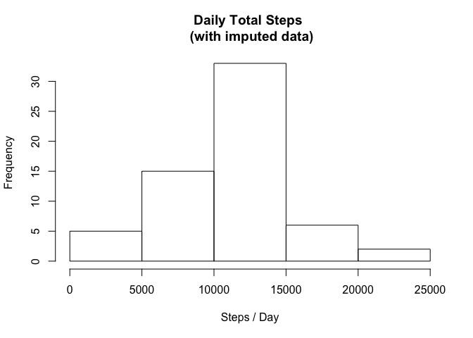

```r
steps_by_day.imp <- activity_imputed %>%
  group_by(date) %>%
  summarise (daily_steps = sum(steps.imp))

hist(round(steps_by_day.imp$daily_steps, 0),
    main = "Daily Total Steps \n (with imputed data)",
    xlab = "Steps / Day")
```

So, on most days the number of steps still lies between 10.000 and 15.000. There’s hardly any visible difference when compared to the histogram that was created using the original (non-imputed) dataset. [Element #7 required for a complete submission (“Histogram of the total number of steps taken each day after missing values are imputed.”)]

```r
mean_total_steps.imp <- activity_imputed %>%
  group_by(date) %>%
  summarise (daily_steps = sum(steps.imp)) %>%
  summarise(mean_total_steps = median(daily_steps, na.rm = TRUE))

mean_steps_imp <- as.integer(round(mean_total_steps.imp$mean_total_steps, 0))
difference_mean <- mean_steps_imp - mean_steps
perc_diff_mean <- round(difference_mean / mean_steps * 100, 1)
```

```r
median_total_steps.imp <- activity_imputed %>%
  group_by(date) %>%
  summarise (daily_steps = sum(steps.imp)) %>%
  summarise(median_total_steps = median(daily_steps, na.rm = TRUE))

median_steps_imp <- as.integer(round(median_total_steps.imp$median_total_steps, 0))
difference_median <- median_steps_imp - median_steps
perc_diff_median <- round(difference_median / median_steps * 100, 1)
```

## Are there differences in activity patterns between weekdays and weekends?

Let’s make a panel plot so that we can make a visual comparison:

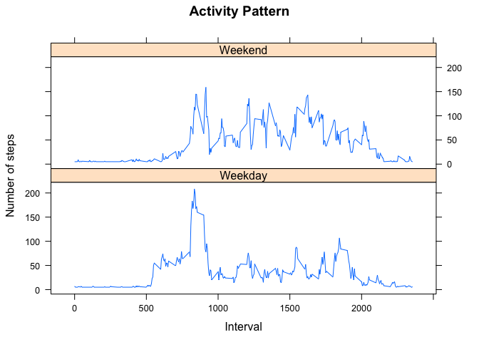

```r
# Using 'activity_imputed'...
# Adding 'day_type' (factor)variable.
# First setting 'day_type' to "Weekend":
activity_imputed$day_type[activity_imputed$weekday == "Saturday" |
                            activity_imputed$weekday == "Sunday"] <- "Weekend"
# Now setting the complement to "Weekday":
activity_imputed$day_type[!(activity_imputed$weekday == "Saturday" |
                            activity_imputed$weekday == "Sunday")] <- "Weekday"
# Coercing 'day_type' to factor variable:
activity_imputed$day_type <- as.factor(activity_imputed$day_type)

# Checking the result by sampling the data:
# activity_imputed[sample(nrow(activity_imputed), 10), ]
# Everything seems to be in order — only Saturdays / Sundays are
# of type "Weekend".

# What is the average daily activity pattern during the weekends?
steps_by_interval_weekend <- activity_imputed %>%
  filter(day_type == "Weekend") %>%
  group_by(interval) %>%
  summarise (av_steps = mean(steps.imp, na.rm = TRUE))

# What is the average daily activity pattern during weekdays?
steps_by_interval_weekdays <- activity_imputed %>%
  filter(day_type == "Weekday") %>%
  group_by(interval) %>%
  summarise (av_steps = mean(steps.imp, na.rm = TRUE))

# Creating 'steps_by_interval.imp', since we need that for the panel plot:
steps_by_interval.imp <- activity_imputed %>%
  # First group activity by interval...
  # Keep day_type (needed for plotting).
  group_by(interval, day_type) %>%
  # Then summarise by summing steps...
  summarise (av_steps = round(mean(steps.imp, na.rm = TRUE), 0))


# Panelplot? Showing weekend and weekdays side by side...
# Judging by the look of the example plot lattice should be used here.
if (!require(lattice)) install.packages("lattice")
library(lattice)

# This code produces the required plot:
xyplot(av_steps ~ interval | day_type, data = steps_by_interval.imp,
       type = "l", layout = c(1,2),
       ylab = "Number of steps",
       xlab = "Interval",
       main = "Activity Pattern")
```

[Element #8 required for a complete submission (“Panel plot comparing the average number of steps taken per 5-minute interval across weekdays and weekends.”)]

There does indeed seem to be a difference in the daily activity when we compare weekends to weekdays.

This (HTML) document was generated by `knitr` from a R Markdown file. This .Rmd file was produced with RStudio. Knitting the R Markdown file reproduces this report exactly.

[Element #9 required for a complete submission (“All of the R code needed to reproduce the results (numbers, plots, etc.) in the report.”)]